# STA 141B Assignment 3

Due **February 24, 2023** by **11:59pm**. Submit by editing this file and then uploading to Canvas.

Please rename this file with **"LastName_FirstName_hw3"**

The purpose of this assignment is to practice reading data using API and web scraping.

Notes:

1. Put your answers in new cells after each exercise. You can make as many new cells as you like. Use code cells for code and Markdown cells for text. Answer all questions with complete sentences.
2. Your code should be readable; writing a piece of code should be compared to writing a page of a book. Adopt the **one-statement-per-line** rule. **The length of your code should not exceed the maximum length of each cell for display.** If your code is too long, you should split it into multiple lines to improve readability. (You will lose one point for each line that does not follow the rule.)
3. To help understand and maintain code, you should always add comments to explain your code. Use the hash symbol (#) to start writing a comment (homework without any comments will automatically receive 0 points). If you are writing a function, consider using *docstring* to add explanation.
4. Submit your final work with a **.pdf** (or a **.html**) file to Canvas. To convert a .ipynb file to a .pdf/.html file, go to "File", click "Download as", and then click "PDF via LaTeX"/"HTML".
5. Please do not clear your output so that we can see your answers without running all of the cells.
6. You may want to re-run your code before submitting your homework as you might find that some code blocks will have bugs if re-run from the start.

### Part I. API

In this part, we will be using the the covidcast api, and you can find [the documentation here](https://cmu-delphi.github.io/delphi-epidata/). We will be using the http api and you **should not** use the `covidcast` python package. Even though it is available, I want to test you on using the requests package and making http requests directly.

```python
import requests
import pandas as pd
import numpy as np
```

Read [the documentation about the Epidata API at this README](https://cmu-delphi.github.io/delphi-epidata/api/covidcast.html) and we will be using the covidcast "endpoint". Pay special attention to the section "Constructing API Queries". You will be making requests with the request package. Consider the following get request...

```
https://api.covidcast.cmu.edu/epidata/api.php?endpoint=covidcast&data_source=fb-survey&signal=smoothed_cli&time_type=day&geo_type=county&time_values=20220101-20220106&geo_value=06001
```

If you put this in your browser you see...

```
{ "epidata": [{"geo_value":"06001","signal":"smoothed_cli","time_value":20220101,"direction":null,"issue":20220106,"lag":5,"missing_value":0,"missing_stderr":0,"missing_sample_size":0,"value":1.4538325,"stderr":0.3291942,"sample_size":1052.6756},{"geo_value":"06001","signal":"smoothed_cli","time_value":20220102,"direction":null,"issue":20220107,"lag":5,"missing_value":0,"missing_stderr":0,"missing_sample_size":0,"value":1.8117667,"stderr":0.3580762,"sample_size":1064.7028},{"geo_value":"06001","signal":"smoothed_cli","time_value":20220103,"direction":null,"issue":20220108,"lag":5,"missing_value":0,"missing_stderr":0,"missing_sample_size":0,"value":2.0777178,"stderr":0.3804188,"sample_size":1093.5003},{"geo_value":"06001","signal":"smoothed_cli","time_value":20220104,"direction":null,"issue":20220109,"lag":5,"missing_value":0,"missing_stderr":0,"missing_sample_size":0,"value":2.4268451,"stderr":0.41568,"sample_size":1105.6993},{"geo_value":"06001","signal":"smoothed_cli","time_value":20220105,"direction":null,"issue":20220110,"lag":5,"missing_value":0,"missing_stderr":0,"missing_sample_size":0,"value":2.3800429,"stderr":0.3922188,"sample_size":1136.6034},{"geo_value":"06001","signal":"smoothed_cli","time_value":20220106,"direction":null,"issue":20220111,"lag":5,"missing_value":0,"missing_stderr":0,"missing_sample_size":0,"value":2.625263,"stderr":0.4066375,"sample_size":1132.8466}], "result": 1, "message": "success" }
```

which is the json returned from this query. The parameters for the query are

```
endpoint=covidcast
data_source=fb-survey
signal=smoothed_cli
time_type=day
geo_type=county
time_values=20220101-20220106
geo_value=06001
```

which asks for the smoothed cli signal from the fb survey data for county 06001 from 2022-01-01 to 2022-01-06. Notice that if you want to select all geo_values then you can set geo_value=*.

**Exercise 1.** Request the value for the smoothed_cli signal from the fb-survey datasource on 2022-01-01 for ALL STATES. Notice that the above is for counties and so you need to change this to states. Do the same for smoothed_hh_cmnty_cli signal from the fb-survey data, and the confirmed_7dav_incidence_prop signal from the jhu-csse data source. Create dataframes from these and join these 3 variables based on the state into a single dataframe. Drop rows with missingness (there should be only about 5 of them dropped this way, corresponding to the US territories). Finally, compute and output the spearman correlation between all variables in this dataframe (there should be 51 rows in the new dataset).

```python
# define a function to generalize http get parameters
def params(data_source,signal):
    return dict( {
"data_source": data_source,
"signal": signal,
"time_type":"day",
"geo_type":"state",
"time_values":list([20220101,20220101]),
"geo_value":"*"
})

# get requests for each data source and signal and extract relevant columns
smoothed_cli = pd.DataFrame(requests.get("https://api.covidcast.cmu.edu/epidata/covidcast/",params = params("fb-survey","smoothed_cli")).json()["epidata"])[["geo_value","signal","value"]]
hh_cmnty = pd.DataFrame(requests.get("https://api.covidcast.cmu.edu/epidata/covidcast/",params = params("fb-survey","smoothed_hh_cmnty_cli")).json()["epidata"])[["geo_value","signal","value"]]
jhu_csse = pd.DataFrame(requests.get("https://api.covidcast.cmu.edu/epidata/covidcast/",params = params("jhu-csse","confirmed_7dav_incidence_prop")).json()["epidata"])[["geo_value","signal","value"]]
pd.merge(pd.merge(smoothed_cli,hh_cmnty, on="geo_value"), jhu_csse, on="geo_value")
```

|  | geo_value | signal_x | value_x | signal_y | value_y | signal | value |
| --- | --- | --- | --- | --- | --- | --- | --- |
| 0 | ak | smoothed_cli | 1.988426 | smoothed_hh_cmnty_cli | 26.718404 | confirmed_7dav_incidence_prop | 36.365002 |
| 1 | al | smoothed_cli | 4.107746 | smoothed_hh_cmnty_cli | 36.076034 | confirmed_7dav_incidence_prop | 82.811032 |
| 2 | ar | smoothed_cli | 2.533740 | smoothed_hh_cmnty_cli | 34.849508 | confirmed_7dav_incidence_prop | 97.342966 |
| 3 | az | smoothed_cli | 2.694759 | smoothed_hh_cmnty_cli | 31.895911 | confirmed_7dav_incidence_prop | 67.372724 |
| 4 | ca | smoothed_cli | 2.357308 | smoothed_hh_cmnty_cli | 29.062623 | confirmed_7dav_incidence_prop | 84.722014 |
| 5 | co | smoothed_cli | 3.208922 | smoothed_hh_cmnty_cli | 38.293050 | confirmed_7dav_incidence_prop | 201.896329 |
| 6 | ct | smoothed_cli | 4.462179 | smoothed_hh_cmnty_cli | 43.893939 | confirmed_7dav_incidence_prop | 143.101891 |
| 7 | dc | smoothed_cli | 4.347457 | smoothed_hh_cmnty_cli | 35.377358 | confirmed_7dav_incidence_prop | 295.027048 |
| 8 | de | smoothed_cli | 3.527615 | smoothed_hh_cmnty_cli | 39.746193 | confirmed_7dav_incidence_prop | 178.309220 |
| 9 | fl | smoothed_cli | 3.966940 | smoothed_hh_cmnty_cli | 34.692345 | confirmed_7dav_incidence_prop | 198.627934 |
| 10 | ga | smoothed_cli | 4.674997 | smoothed_hh_cmnty_cli | 43.604375 | confirmed_7dav_incidence_prop | 141.761813 |
| 11 | hi | smoothed_cli | 1.479807 | smoothed_hh_cmnty_cli | 30.054274 | confirmed_7dav_incidence_prop | 156.949275 |
| 12 | ia | smoothed_cli | 3.571186 | smoothed_hh_cmnty_cli | 34.649496 | confirmed_7dav_incidence_prop | 52.138352 |
| 13 | id | smoothed_cli | 2.597932 | smoothed_hh_cmnty_cli | 30.890673 | confirmed_7dav_incidence_prop | 28.588428 |
| 14 | il | smoothed_cli | 3.758624 | smoothed_hh_cmnty_cli | 43.691680 | confirmed_7dav_incidence_prop | 145.556753 |
| 15 | in | smoothed_cli | 3.589440 | smoothed_hh_cmnty_cli | 41.839739 | confirmed_7dav_incidence_prop | 97.130844 |
| 16 | ks | smoothed_cli | 3.516681 | smoothed_hh_cmnty_cli | 38.640400 | confirmed_7dav_incidence_prop | 68.849592 |
| 17 | ky | smoothed_cli | 3.048790 | smoothed_hh_cmnty_cli | 37.838539 | confirmed_7dav_incidence_prop | 62.870211 |
| 18 | la | smoothed_cli | 5.277630 | smoothed_hh_cmnty_cli | 43.678713 | confirmed_7dav_incidence_prop | 117.851381 |
| 19 | ma | smoothed_cli | 3.268883 | smoothed_hh_cmnty_cli | 39.893918 | confirmed_7dav_incidence_prop | 176.344355 |
| 20 | md | smoothed_cli | 4.124256 | smoothed_hh_cmnty_cli | 44.394312 | confirmed_7dav_incidence_prop | 176.053123 |
| 21 | me | smoothed_cli | 2.066833 | smoothed_hh_cmnty_cli | 30.973130 | confirmed_7dav_incidence_prop | 52.438967 |
| 22 | mi | smoothed_cli | 2.726807 | smoothed_hh_cmnty_cli | 37.142181 | confirmed_7dav_incidence_prop | 92.459230 |
| 23 | mn | smoothed_cli | 2.962201 | smoothed_hh_cmnty_cli | 32.848129 | confirmed_7dav_incidence_prop | 65.623953 |
| 24 | mo | smoothed_cli | 3.102227 | smoothed_hh_cmnty_cli | 38.944373 | confirmed_7dav_incidence_prop | 75.788124 |
| 25 | ms | smoothed_cli | 5.022875 | smoothed_hh_cmnty_cli | 40.099449 | confirmed_7dav_incidence_prop | 87.805457 |
| 26 | mt | smoothed_cli | 1.864521 | smoothed_hh_cmnty_cli | 27.648047 | confirmed_7dav_incidence_prop | 27.168025 |
| 27 | nc | smoothed_cli | 2.975413 | smoothed_hh_cmnty_cli | 33.742756 | confirmed_7dav_incidence_prop | 106.850195 |
| 28 | nd | smoothed_cli | 1.819514 | smoothed_hh_cmnty_cli | 32.233819 | confirmed_7dav_incidence_prop | 62.085100 |
| 29 | ne | smoothed_cli | 3.388058 | smoothed_hh_cmnty_cli | 35.954077 | confirmed_7dav_incidence_prop | 52.909179 |
| 30 | nh | smoothed_cli | 1.979628 | smoothed_hh_cmnty_cli | 34.947447 | confirmed_7dav_incidence_prop | 90.757717 |
| 31 | nj | smoothed_cli | 5.206864 | smoothed_hh_cmnty_cli | 47.372202 | confirmed_7dav_incidence_prop | 268.409672 |
| 32 | nm | smoothed_cli | 2.831049 | smoothed_hh_cmnty_cli | 30.258192 | confirmed_7dav_incidence_prop | 50.148421 |
| 33 | nv | smoothed_cli | 2.408068 | smoothed_hh_cmnty_cli | 29.376235 | confirmed_7dav_incidence_prop | 48.334352 |
| 34 | ny | smoothed_cli | 3.718063 | smoothed_hh_cmnty_cli | 38.789738 | confirmed_7dav_incidence_prop | 307.093592 |
| 35 | oh | smoothed_cli | 4.326209 | smoothed_hh_cmnty_cli | 48.325051 | confirmed_7dav_incidence_prop | 128.406555 |
| 36 | ok | smoothed_cli | 3.267452 | smoothed_hh_cmnty_cli | 35.448958 | confirmed_7dav_incidence_prop | 52.853924 |
| 37 | or | smoothed_cli | 1.755145 | smoothed_hh_cmnty_cli | 23.502542 | confirmed_7dav_incidence_prop | 36.031668 |
| 38 | pa | smoothed_cli | 3.287780 | smoothed_hh_cmnty_cli | 40.973751 | confirmed_7dav_incidence_prop | 125.123518 |
| 39 | ri | smoothed_cli | 3.250046 | smoothed_hh_cmnty_cli | 37.932890 | confirmed_7dav_incidence_prop | 187.408571 |
| 40 | sc | smoothed_cli | 3.294631 | smoothed_hh_cmnty_cli | 34.606172 | confirmed_7dav_incidence_prop | 84.175010 |
| 41 | sd | smoothed_cli | 4.380466 | smoothed_hh_cmnty_cli | 37.114721 | confirmed_7dav_incidence_prop | 57.052003 |
| 42 | tn | smoothed_cli | 3.781100 | smoothed_hh_cmnty_cli | 39.032943 | confirmed_7dav_incidence_prop | 135.706148 |
| 43 | tx | smoothed_cli | 4.340773 | smoothed_hh_cmnty_cli | 40.881133 | confirmed_7dav_incidence_prop | 69.432323 |
| 44 | ut | smoothed_cli | 2.902034 | smoothed_hh_cmnty_cli | 34.117618 | confirmed_7dav_incidence_prop | 58.415362 |
| 45 | va | smoothed_cli | 4.099853 | smoothed_hh_cmnty_cli | 39.998854 | confirmed_7dav_incidence_prop | 115.046509 |
| 46 | vt | smoothed_cli | 1.679158 | smoothed_hh_cmnty_cli | 30.655193 | confirmed_7dav_incidence_prop | 95.842055 |
| 47 | wa | smoothed_cli | 2.297944 | smoothed_hh_cmnty_cli | 28.708417 | confirmed_7dav_incidence_prop | 65.609161 |
| 48 | wi | smoothed_cli | 2.942571 | smoothed_hh_cmnty_cli | 37.361768 | confirmed_7dav_incidence_prop | 91.164070 |
| 49 | wv | smoothed_cli | 3.339840 | smoothed_hh_cmnty_cli | 38.660839 | confirmed_7dav_incidence_prop | 73.053935 |
| 50 | wy | smoothed_cli | 2.528523 | smoothed_hh_cmnty_cli | 31.050943 | confirmed_7dav_incidence_prop | 34.246777 |

```python
# merge all three dataframes together and calculate the spearman correlation
corr_df = pd.merge(pd.merge(smoothed_cli,hh_cmnty, on="geo_value"), jhu_csse, on="geo_value").corr(method = "spearman")
# rename columns
corr_df.columns = ["smoothed_cli","hh_cmnty","jhu_csse"]
# rename rows
corr_df = corr_df.rename(index={"value_x": "smoothed_cli", "value_y": "hh_cmnty", "value": "jhu_csse"})

corr_df
```

|  | smoothed_cli | hh_cmnty | jhu_csse |
| --- | --- | --- | --- |
| smoothed_cli | 1.000000 | 0.82000 | 0.501719 |
| hh_cmnty | 0.820000 | 1.00000 | 0.630950 |
| jhu_csse | 0.501719 | 0.63095 | 1.000000 |

### Part II. Web scraping

We will start by web scraping the following webpage: `https://ycharts.com/indicators/sp_500_market_cap`. Start by looking at the html (either through the dev tools for your browser or by viewing source). We will be extracting the market cap data in the table displayed below.

[figure not shown]

You should use the `requests` package to read html and convert into a beautifulsoup object. We only briefly mentioned beautifulsoup in the class, now it is the time for you to google and learn it by yourself. You can find its documentation [here](https://beautiful-soup-4.readthedocs.io/en/latest/).

To start, you can import beautifulsoup to your ipythone notebook by typing:

```
from bs4 import BeautifulSoup
```

You may also need to import the `lxml` package

```
import lxml
```

```python
from bs4 import BeautifulSoup
import lxml
```

**Exercise 2.** Find the table displayed above, using the `find_all` method. Then print the html for this table using `print(table_found.prettify())` if `table_found` is the BeautifulSoup object corresponding to the table of interest.

Some of you may find that there is a "paywall" if you request too many times. I have also included the html file for you in `sp_500_market_cap.html`. If the request does not work for that reason you can read it in with the following

```
with open('sp_500_market_cap.html','r') as file_ob:
    req_text = file_ob.read()
```

```python
# read local html file
with open('sp_500_market_cap.html','r') as file_ob:
    req_text = file_ob.read()

# initialize the BeautifulSoup object
soup = BeautifulSoup(req_text)
# find all tables
tables = soup.find_all("table")
# init an empty list
market_cap_tables = []

# iterate over all tables
for table in tables:
    # find the table head
    thead = table.find("thead")
    # find tables that contain Date in the header
    if thead and "Date" in thead.text:
        # append table html to a list
        market_cap_tables.append(table)

# print out the html for the 2 matching tables
for table in market_cap_tables:
    print(table.prettify())
```

```
<table class="table">
 <thead>
  <tr>
   <th>
    Date
   </th>
   <th class="text-right">
    Value
   </th>
  </tr>
 </thead>
 <tbody>
  <tr>
   <td>
    December 31, 2022
   </td>
   <td class="text-right">
    32.13T
   </td>
  </tr>
  <tr>
   <td>
    September 30, 2022
   </td>
   <td class="text-right">
    30.12T
   </td>
  </tr>
  <tr>
   <td>
    June 30, 2022
   </td>
   <td class="text-right">
    31.90T
   </td>
  </tr>
  <tr>
   <td>
    March 31, 2022
   </td>
```

[output cut: 374 more lines]

```
   </td>
   <td class="text-right">
    11.43T
   </td>
  </tr>
  <tr>
   <td>
    September 30, 2010
   </td>
   <td class="text-right">
    10.34T
   </td>
  </tr>
 </tbody>
</table>
```

*Hint: the first few lines after you type `print(table_found.prettify())` should looks like this:*

[figure not shown]

**Exercise 3.** Find all of the table rows in this table that contain the market cap data. Convert this into a pandas dataframe that contains a 'date' variable and 'market_cap' variable where 'date' is a datetime object, and 'market_cap' is a float. Plot this timeseries. You can choose matplotlib, plotnine, or seaborn. The plot must have x-axis and y-axis and a title.

```python
import itertools

# init another list for dfs
dfs = []
# iterate over the 2 html tables
for table in market_cap_tables:
    # append the dfs from the html
    dfs.append(pd.read_html(str(table)))

# flatten the nested lists and concat into one df
plot_df = pd.concat(list(itertools.chain(*dfs)))

plot_df.head()
```

|  | Date | Value |
| --- | --- | --- |
| 0 | December 31, 2022 | 32.13T |
| 1 | September 30, 2022 | 30.12T |
| 2 | June 30, 2022 | 31.90T |
| 3 | March 31, 2022 | 38.29T |
| 4 | December 31, 2021 | 40.36T |

```python
# change Date column to datetime
plot_df["Date"] = pd.to_datetime(plot_df["Date"])
# remove the "T" from the Value column
plot_df["Value"] = plot_df["Value"].str[:-1]
# change the Value column to a float
plot_df["Value"] = plot_df["Value"].astype(float)
# Change column name
plot_df = plot_df.rename(columns={"Value": "market_cap"})
# resent the df index
plot_df = plot_df.reset_index()
```

[output not shown]

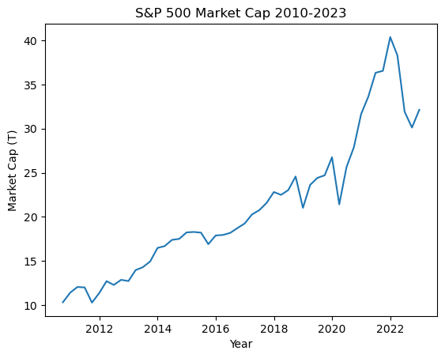

```python
import seaborn as sns
# create a line plot
sns.lineplot(x = "Date",y = "market_cap",data = plot_df).set(title='S&P 500 Market Cap 2010-2023', ylabel = "Market Cap (T)", xlabel = "Year")
```